# Class Project Report

Tree Health: Penn State Altoona

Sarah Allen

December 8, 2024

## Research / Guiding Questions

Which tree species on the Penn State Altoona campus has the highest incidence of causing damage due to its location and condition risk? How do the at risk trees on the Penn State Altoona campus compare (e.g., species) to the tree species in parks in the city of Portland, Oregon? What else can R do to help us learn more about Altoona campus and Portland, Oregon trees?

```r
# clean up R environment
rm(list = ls())

# load necessary packages
library(tidyverse)
library(dplyr)
library(esquisse)
library(ggplot2)
library(tidyr)
library(stringr)
library(pdxTrees)  # Package contains secondary data source including information about trees in the city of Portland, Oregon, USA
```

```r
AltoonaTrees <- read.csv("Altoona_Trees_Assigned_Risk.csv") # Data that is NOT from an R package

head(AltoonaTrees)
```

|  | Tree.ID | Common.Name | Scientific_Name | Genus | Family | DBH | Condition.Class | Overall.Tree.Risk.Rating | Tree.and.Shrub.Work.Phase | Prune | Pruning.Goal.1 | Removal | Primary.Target | Secondary.Target | Plant.Part.of.Concern | Likelihood.Failure | Likelihood.Impact | Likelihood.of.Failure.and.Impact | Consequences.of.Failure | Advanced.Assessment.Stem | Advanced.Assessment.Crown |
| --- | --- | --- | --- | --- | --- | --- | --- | --- | --- | --- | --- | --- | --- | --- | --- | --- | --- | --- | --- | --- | --- |
| 1 | 2759 | Ash-White | Fraxinus americana | Fraxinus | Oleaceae | 8 | Dead | High | 1 | ... | ... | Remove | Walking path | ... | Stem | Imminent | Medium | Likely | Severe | ... | ... |
| 2 | 2707 | Cherry-Black | Prunus serotina | Prunus | Rosaceae | 30 | Poor | Moderate | 1 | ... | ... | Remove | Sidewalk | ... | Crown | Probable | Medium | Somewhat likely | Severe | ... | ... |
| 3 | 53 | Oak-Northern Red | Quercus rubra | Quercus | Fagaceae | 19 | Poor | Moderate | 1 | ... | ... | Remove | Walking path | ... | Branches | Probable | Medium | Somewhat likely | Severe | ... | ... |
| 4 | 58 | Oak-Northern Red | Quercus rubra | Quercus | Fagaceae | 14 | Poor | Moderate | 1 | Yes | Reduce risk of branch stem and/or root failure | ... | Walking path | ... | Branches | Probable | Medium | Somewhat likely | Severe | ... | ... |
| 5 | 61 | Oak-White | Quercus alba | Quercus | Fagaceae | 32 | Fair | Moderate | 1 | Yes | Reduce risk of branch stem and/or root failure | ... | Walking path | ... | Branches | Probable | Medium | Somewhat likely | Severe | ... | ... |
| 6 | 82 | Oak-Scarlet | Quercus coccinea | Quercus | Fagaceae | 28 | Fair | Moderate | 1 | Yes | Reduce risk of branch stem and/or root failure | ... | Parking | ... | Branches | Probable | Medium | Somewhat likely | Severe | ... | ... |

```r
str(AltoonaTrees)
```

```
'data.frame':   139 obs. of  21 variables:
 $ Tree.ID                         : int  2759 2707 53 58 61 82 117 248 261 263 ...
 $ Common.Name                     : chr  "Ash-White " "Cherry-Black " "Oak-Northern Red " "Oak-Northern Red " ...
 $ Scientific_Name                 : chr  "Fraxinus americana" "Prunus serotina" "Quercus rubra" "Quercus rubra" ...
 $ Genus                           : chr  "Fraxinus" "Prunus" "Quercus" "Quercus" ...
 $ Family                          : chr  "Oleaceae" "Rosaceae" "Fagaceae" "Fagaceae" ...
 $ DBH                             : int  8 30 19 14 32 28 21 32 42 23 ...
 $ Condition.Class                 : chr  "Dead" "Poor" "Poor" "Poor" ...
 $ Overall.Tree.Risk.Rating        : chr  "High" "Moderate" "Moderate" "Moderate" ...
 $ Tree.and.Shrub.Work.Phase       : int  1 1 1 1 1 1 1 1 1 1 ...
 $ Prune                           : chr  "..." "..." "..." "Yes" ...
 $ Pruning.Goal.1                  : chr  "..." "..." "..." "Reduce risk of branch stem and/or root failure" ...
 $ Removal                         : chr  "Remove" "Remove" "Remove" "..." ...
 $ Primary.Target                  : chr  "Walking path" "Sidewalk" "Walking path" "Walking path" ...
 $ Secondary.Target                : chr  "..." "..." "..." "..." ...
 $ Plant.Part.of.Concern           : chr  "Stem" "Crown" "Branches" "Branches" ...
 $ Likelihood.Failure              : chr  "Imminent" "Probable" "Probable" "Probable" ...
 $ Likelihood.Impact               : chr  "Medium" "Medium" "Medium" "Medium" ...
 $ Likelihood.of.Failure.and.Impact: chr  "Likely" "Somewhat likely" "Somewhat likely" "Somewhat likely" ...
 $ Consequences.of.Failure         : chr  "Severe" "Severe" "Severe" "Severe" ...
 $ Advanced.Assessment.Stem        : chr  "..." "..." "..." "..." ...
 $ Advanced.Assessment.Crown       : chr  "..." "..." "..." "..." ...
```

## Become Acquainted with data source: Altoona Trees

Where: I have access as the Altoona representative for the Commonwealth Arboreta Network. Who: Collected by Barlett Tree Experts. When & Why: Collected in summer 2024 as part of a multi-campus tree inventory. Cases: Each case represents an individual tree on the Altoona campus that poses some risk to people or property. 139 cases.  
Variables of interest:scientific name, DBH (diameter at breast height), condition, etc.

## Become Acquainted with data source: Portland Trees

Where: Data within an R package (pdxTrees). Who: Data collected by staff and volunteers. When & Why: Trees were inventoried in 2017, 2018, and 2019. Cases: Each case is one tree at a specific latitude and longitude found in a Portland, OR park. 25,534 cases. Variables of interest: scientific name, DBH (diameter at breast height), condition, etc.

## Altoona Trees: Summary statistics of DBH (diameter at breast height)

```r
# Using reduction functions to learn about DBH

# Obtain Mean DBH Value with Base R methods
mean_DBH_baseR <- mean(AltoonaTrees$DBH, na.rm = TRUE)
print(mean_DBH_baseR)
```

```
[1] 23.96403
```

```r
# Obtain Mean DBH Value Value with TidyVerse methods (creates a new dataframe)
mean_DBH <-
  AltoonaTrees %>%
  summarize(mean_column = mean(DBH, na.rm = TRUE))

mean_DBH
```

| mean_column |
| --- |
| 23.96403 |

```r
# Determine min and max DBH values of Altoona Trees
min_DBH_baseR <-
  min(AltoonaTrees$DBH, na.rm = TRUE)

min_DBH_baseR
```

```
[1] 5
```

```r
max_DBH_baseR <-
  max(AltoonaTrees$DBH, na.rm = TRUE)

max_DBH_baseR
```

```
[1] 49
```

## Altoona Trees: Plots

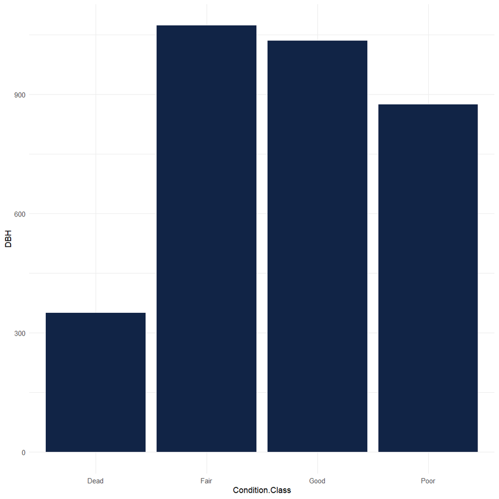

```r
ggplot(AltoonaTrees) +
 aes(x = Condition.Class, y = DBH) +
 geom_col(fill = "#112446") +
 theme_minimal()
```

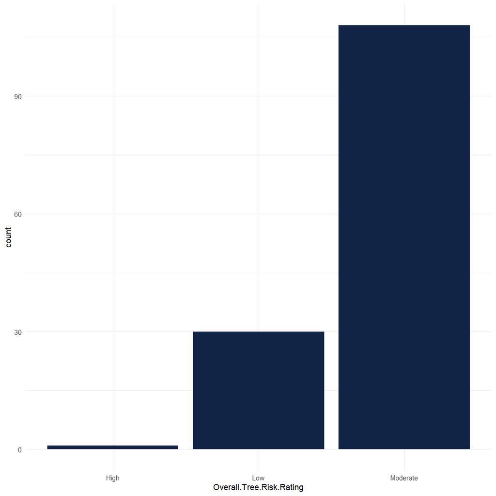

```r
ggplot(AltoonaTrees) +
 aes(x = Overall.Tree.Risk.Rating, colour = Overall.Tree.Risk.Rating, group = Common.Name) +
 geom_bar(fill = "#112446") +
 scale_color_hue(direction = 1) +
 theme_minimal()
```

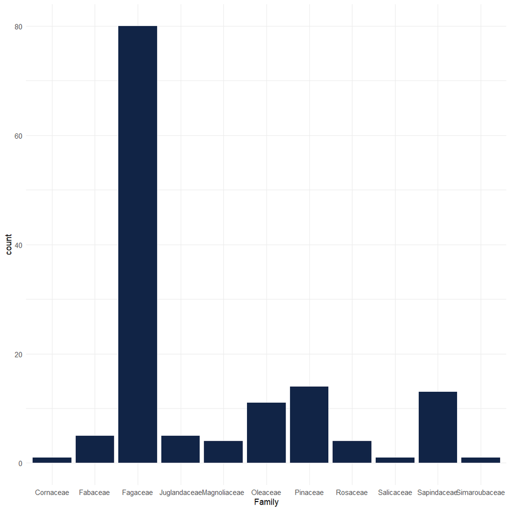

```r
ggplot(AltoonaTrees) +
 aes(x = Family) +
 geom_bar(fill = "#112446") +
 theme_minimal()
```

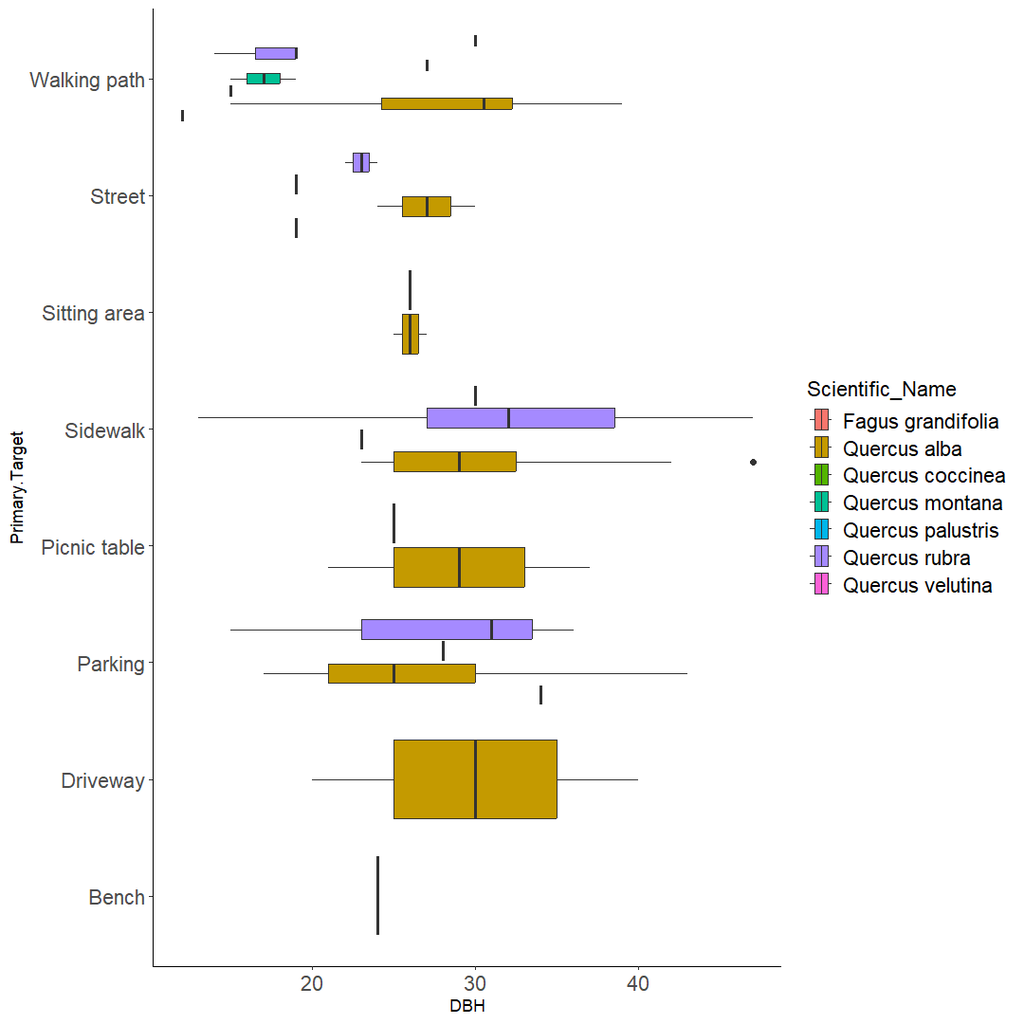

```r
# Filtering the AltoonaTrees dataset to focus on only the Fagaceae (oak and beech) plant family.
Altoona_Fagaceae <-
  AltoonaTrees %>%
  filter(Family == "Fagaceae")

ggplot(Altoona_Fagaceae) +
 aes(x = DBH, y = Primary.Target, fill = Scientific_Name) +
 geom_boxplot() +
 scale_fill_hue(direction = 1) +
 theme_classic() +
 theme(axis.text.y = element_text(size = 13L), axis.text.x = element_text(size = 13L),
 legend.text = element_text(size = 13L), legend.title = element_text(size = 13L))
```

## View Second Data Source: Trees in parks in Portland, Oregon

From R package “pdxTrees”

```r
pdxTrees_parks <- get_pdxTrees_parks()
str(pdxTrees_parks)
```

```
spc_tbl_ [25,534 × 34] (S3: spec_tbl_df/tbl_df/tbl/data.frame)
 $ Longitude                 : num [1:25534] -123 -123 -123 -123 -123 ...
 $ Latitude                  : num [1:25534] 45.6 45.6 45.6 45.6 45.6 ...
 $ UserID                    : chr [1:25534] "1" "2" "3" "4" ...
 $ Genus                     : chr [1:25534] "Pseudotsuga" "Pseudotsuga" "Crataegus" "Quercus" ...
 $ Family                    : chr [1:25534] "Pinaceae" "Pinaceae" "Rosaceae" "Fagaceae" ...
 $ DBH                       : num [1:25534] 37.4 32.5 9.7 10.3 33.2 32.1 28.4 27.2 35.2 32.4 ...
 $ Inventory_Date            : POSIXct[1:25534], format: "2017-05-09" "2017-05-09" "2017-05-09" ...
 $ Species                   : chr [1:25534] "PSME" "PSME" "CRLA" "QURU" ...
 $ Common_Name               : chr [1:25534] "Douglas-Fir" "Douglas-Fir" "Lavalle Hawthorn" "Northern Red Oak" ...
 $ Condition                 : chr [1:25534] "Fair" "Fair" "Fair" "Poor" ...
 $ Tree_Height               : num [1:25534] 105 94 23 28 102 95 103 105 97 112 ...
 $ Crown_Width_NS            : num [1:25534] 44 49 28 38 43 35 40 45 56 35 ...
 $ Crown_Width_EW            : num [1:25534] 57 45 27 31 44 39 40 29 45 33 ...
 $ Crown_Base_Height         : num [1:25534] 4 4 3 5 4 12 6 13 5 17 ...
 $ Collected_By              : chr [1:25534] "Staff" "Staff" "Staff" "Staff" ...
 $ Park                      : chr [1:25534] "Gammans Park" "Gammans Park" "Gammans Park" "Gammans Park" ...
 $ Scientific_Name           : chr [1:25534] "Pseudotsuga menziesii" "Pseudotsuga menziesii" "Crataegus x lavalleei" "Quercus rubra" ...
 $ Functional_Type           : chr [1:25534] "CE" "CE" "BD" "BD" ...
 $ Mature_Size               : Factor w/ 3 levels "L","S","M": 1 1 2 1 1 1 1 1 1 1 ...
 $ Native                    : chr [1:25534] "Yes" "Yes" "No" "No" ...
 $ Edible                    : chr [1:25534] NA NA NA NA ...
 $ Nuisance                  : chr [1:25534] NA NA NA NA ...
 $ Structural_Value          : num [1:25534] 10101 7901 1111 525 8225 ...
 $ Carbon_Storage_lb         : num [1:25534] 3223 2461 310 400 2533 ...
 $ Carbon_Storage_value      : num [1:25534] 209.1 159.6 20.1 25.9 164.3 ...
 $ Carbon_Sequestration_lb   : num [1:25534] 36.8 31.3 14.8 6 32 30.8 26.8 25.5 34.3 31.1 ...
 $ Carbon_Sequestration_value: num [1:25534] 2.39 2.03 0.96 0.39 2.08 2 1.74 1.65 2.22 2.02 ...
 $ Stormwater_ft             : num [1:25534] 150.3 133 35.4 38.3 115.5 ...
 $ Stormwater_value          : num [1:25534] 10.05 8.89 2.37 2.56 7.72 ...
 $ Pollution_Removal_value   : num [1:25534] 18.25 16.15 4.31 4.65 14.03 ...
 $ Pollution_Removal_oz      : num [1:25534] 40.4 35.8 9.5 10.3 31.1 22.9 26.8 22.9 39.9 19.4 ...
 $ Total_Annual_Services     : num [1:25534] 30.69 27.06 7.64 7.59 23.82 ...
 $ Origin                    : chr [1:25534] "North America - from British Columbia south to Oregon, Washington, California, Idaho and western Montana with a"| __truncated__ "North America - from British Columbia south to Oregon, Washington, California, Idaho and western Montana with a"| __truncated…
 $ Species_Factoid           : chr [1:25534] "Bracts on cones look like a mouse's feet and tail." "Bracts on cones look like a mouse's feet and tail." "Like most hawthorns, the tree has stout thorns up to 2\" long." "Acorns take two years to mature and are an important food source for wildlife." ...
 - attr(*, "spec")=
  .. cols(
  ..   Longitude = col_double(),
  ..   Latitude = col_double(),
  ..   UserID = col_character(),
```

[output cut: 18 more lines]

```
  ..   Nuisance = col_character(),
  ..   Structural_Value = col_double(),
  ..   Carbon_Storage_lb = col_double(),
  ..   Carbon_Storage_value = col_double(),
  ..   Carbon_Sequestration_lb = col_double(),
  ..   Carbon_Sequestration_value = col_double(),
  ..   Stormwater_ft = col_double(),
  ..   Stormwater_value = col_double(),
  ..   Pollution_Removal_value = col_double(),
  ..   Pollution_Removal_oz = col_double(),
  ..   Total_Annual_Services = col_double(),
  ..   Origin = col_character(),
  ..   Species_Factoid = col_character()
  .. )
 - attr(*, "problems")=<externalptr>
```

```r
head(pdxTrees_parks)
```

| Longitude | Latitude | UserID | Genus | Family | DBH | Inventory_Date | Species | Common_Name | Condition | Tree_Height | Crown_Width_NS | Crown_Width_EW | Crown_Base_Height | Collected_By | Park | Scientific_Name | Functional_Type | Mature_Size | Native | Edible | Nuisance | Structural_Value | Carbon_Storage_lb | Carbon_Storage_value | Carbon_Sequestration_lb | Carbon_Sequestration_value | Stormwater_ft | Stormwater_value | Pollution_Removal_value | … |
| --- | --- | --- | --- | --- | --- | --- | --- | --- | --- | --- | --- | --- | --- | --- | --- | --- | --- | --- | --- | --- | --- | --- | --- | --- | --- | --- | --- | --- | --- | --- |
| -122.6936 | 45.57491 | 1 | Pseudotsuga | Pinaceae | 37.4 | 2017-05-09 | PSME | Douglas-Fir | Fair | 105 | 44 | 57 | 4 | Staff | Gammans Park | Pseudotsuga menziesii | CE | L | Yes | NA | NA | 10101.06 | 3223.3 | 209.07 | 36.8 | 2.39 | 150.3 | 10.05 | 18.25 | … |
| -122.6938 | 45.57489 | 2 | Pseudotsuga | Pinaceae | 32.5 | 2017-05-09 | PSME | Douglas-Fir | Fair | 94 | 49 | 45 | 4 | Staff | Gammans Park | Pseudotsuga menziesii | CE | L | Yes | NA | NA | 7900.55 | 2460.8 | 159.62 | 31.3 | 2.03 | 133.0 | 8.89 | 16.15 | … |
| -122.6942 | 45.57493 | 3 | Crataegus | Rosaceae | 9.7 | 2017-05-09 | CRLA | Lavalle Hawthorn | Fair | 23 | 28 | 27 | 3 | Staff | Gammans Park | Crataegus x lavalleei | BD | S | No | NA | NA | 1110.81 | 310.3 | 20.13 | 14.8 | 0.96 | 35.4 | 2.37 | 4.31 | … |
| -122.6939 | 45.57490 | 4 | Quercus | Fagaceae | 10.3 | 2017-05-09 | QURU | Northern Red Oak | Poor | 28 | 38 | 31 | 5 | Staff | Gammans Park | Quercus rubra | BD | L | No | NA | NA | 525.26 | 400.1 | 25.95 | 6.0 | 0.39 | 38.3 | 2.56 | 4.65 | … |
| -122.6940 | 45.57491 | 5 | Pseudotsuga | Pinaceae | 33.2 | 2017-05-09 | PSME | Douglas-Fir | Fair | 102 | 43 | 44 | 4 | Staff | Gammans Park | Pseudotsuga menziesii | CE | L | Yes | NA | NA | 8224.54 | 2533.4 | 164.33 | 32.0 | 2.08 | 115.5 | 7.72 | 14.03 | … |
| -122.6943 | 45.57489 | 6 | Pseudotsuga | Pinaceae | 32.1 | 2017-05-09 | PSME | Douglas-Fir | Fair | 95 | 35 | 39 | 12 | Staff | Gammans Park | Pseudotsuga menziesii | CE | L | Yes | NA | NA | 7713.96 | 2333.7 | 151.38 | 30.8 | 2.00 | 85.3 | 5.70 | 10.36 | … |

## Portland Trees: Summary statistics for Tree Height & DBH

Using reduction functions to learn more about Portland park trees.

```r
mean_DBH_Portland <-
  pdxTrees_parks %>%
  summarize(meanDBH = mean(DBH, na.rm = TRUE))

mean_DBH_Portland
```

| meanDBH |
| --- |
| 20.61408 |

```r
mean_height_Portland <-
  pdxTrees_parks %>%
  summarize(meanHeight = mean(Tree_Height, na.rm = TRUE))

mean_height_Portland
```

| meanHeight |
| --- |
| 65.73607 |

The diameter at breast height (measured at 4.5 feet above the ground) averaged to 20.6 inches. Note: Assuming inches because they used feet, but the R Documentation for pdxTrees_parks does not explicitly say units for any variable, unfortunately. The mean height was 65.7 feet. Once again I am assuming feet rather than meters.

## Informative Plots about Portland, Oregon park trees

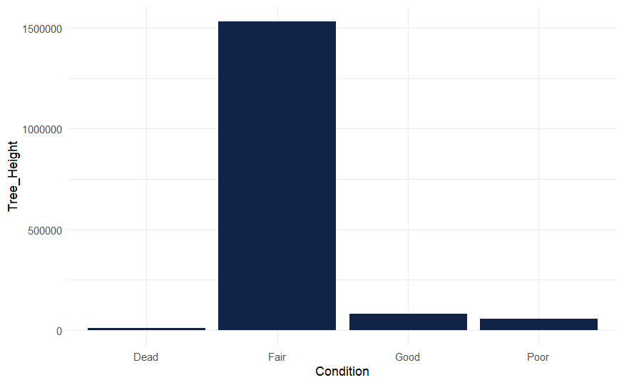

```r
ggplot(pdxTrees_parks) +
 aes(x = Condition, y = Tree_Height) +
 geom_col(fill = "#112446") +
 theme_minimal()
```

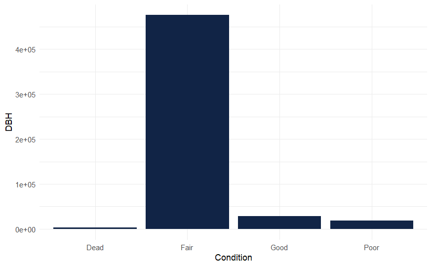

```r
ggplot(pdxTrees_parks) +
 aes(x = Condition, y = DBH) +
 geom_col(fill = "#112446") +
 theme_minimal()
```

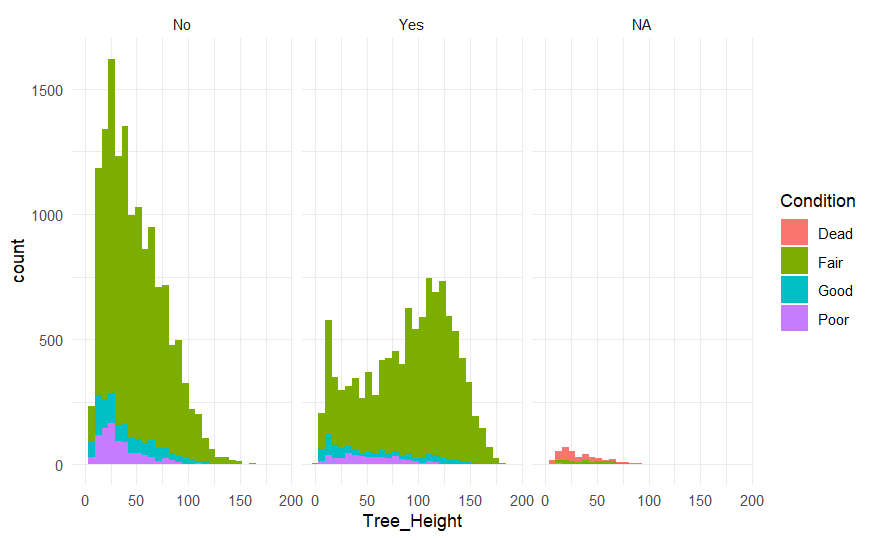

```r
ggplot(pdxTrees_parks) +
 aes(x = Tree_Height, fill = Condition) +
 geom_histogram(bins = 30L) +
 scale_fill_hue(direction = 1) +
 theme_minimal() +
 facet_wrap(vars(Native))
```

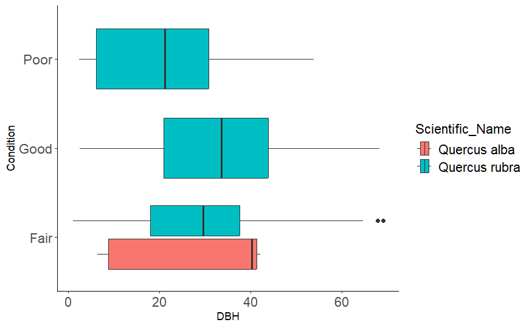

```r
# Filtering the Portland park dataset to focus only on the species Quercus rubra and Quercus alba that are also common on the Altoona campus.
Portland_Fagaceae <-
  pdxTrees_parks %>%
  filter(Scientific_Name == "Quercus rubra" | Scientific_Name == "Quercus alba")

ggplot(Portland_Fagaceae) +
 aes(x = DBH, y = Condition, fill = Scientific_Name) +
 geom_boxplot() +
 scale_fill_hue(direction = 1) +
 theme_classic() +
 theme(axis.text.y = element_text(size = 13L), axis.text.x = element_text(size = 13L),
 legend.text = element_text(size = 13L), legend.title = element_text(size = 13L))
```

## Additional Information about data sources

Using more data verbs.

```r
AltoonaTreesSpecies <-
  AltoonaTrees %>%
  group_by(Scientific_Name) %>%
  summarise(count = n()) %>%
  arrange(desc(count))

head(AltoonaTreesSpecies, n = 10)
```

| Scientific_Name | count |
| --- | --- |
| Quercus alba | 45 |
| Quercus rubra | 20 |
| Acer rubrum | 9 |
| Fraxinus pennsylvanica | 6 |
| Fraxinus americana | 5 |
| Robinia pseudoacacia | 5 |
| Liriodendron tulipifera | 4 |
| Prunus serotina | 4 |
| Quercus montana | 4 |
| Carya ovata | 3 |

```r
PortlandTreeSpecies <-
  pdxTrees_parks %>%
  group_by(Scientific_Name) %>%
  summarise(count = n()) %>%
  arrange(desc(count))

head(PortlandTreeSpecies, n = 10)
```

| Scientific_Name | count |
| --- | --- |
| Pseudotsuga menziesii | 6783 |
| Acer platanoides | 1502 |
| Thuja plicata | 964 |
| Quercus rubra | 736 |
| Quercus palustris | 619 |
| Calocedrus decurrens | 507 |
| Acer macrophyllum | 490 |
| Prunus serrulata | 418 |
| Ulmus americana | 379 |
| Sequoiadendron giganteum | 349 |

**Notes on Comparing the Datasets:** Both datasets have multiple species of *Quercus* (oak) in the top 10. *Quercus rubra* is common to the top 10 of both datasets. Oaks are a very important hardwood in North America. The Altoona dataset does not have any softwoods in the top 10, but the most abudant species in Portland parks is a softwood *Pseudotsuga menziesii* (Douglas fir). Species of *Prunus* (i.e., cherries, plums) and *Acer* (maples) are also common in both locations.

## Join Data Frames using the Scientific name of species

```r
BothLocations <-
  inner_join(AltoonaTrees, pdxTrees_parks, by = "Scientific_Name")
head(BothLocations)
```

|  | Tree.ID | Common.Name | Scientific_Name | Genus.x | Family.x | DBH.x | Condition.Class | Overall.Tree.Risk.Rating | Tree.and.Shrub.Work.Phase | Prune | Pruning.Goal.1 | Removal | Primary.Target | Secondary.Target | Plant.Part.of.Concern | Likelihood.Failure | Likelihood.Impact | Likelihood.of.Failure.and.Impact | Consequences.of.Failure | Advanced.Assessment.Stem | Advanced.Assessment.Crown | Longitude | Latitude | UserID | Genus.y | Family.y | DBH.y | Inventory_Date | Species | … |
| --- | --- | --- | --- | --- | --- | --- | --- | --- | --- | --- | --- | --- | --- | --- | --- | --- | --- | --- | --- | --- | --- | --- | --- | --- | --- | --- | --- | --- | --- | --- |
| 1 | 2759 | Ash-White | Fraxinus americana | Fraxinus | Oleaceae | 8 | Dead | High | 1 | ... | ... | Remove | Walking path | ... | Stem | Imminent | Medium | Likely | Severe | ... | ... | -122.6823 | 45.59786 | 2315 | Fraxinus | Oleaceae | 4.2 | 2017-05-15 | FRAM | … |
| 2 | 2759 | Ash-White | Fraxinus americana | Fraxinus | Oleaceae | 8 | Dead | High | 1 | ... | ... | Remove | Walking path | ... | Stem | Imminent | Medium | Likely | Severe | ... | ... | -122.6718 | 45.57950 | 98 | Fraxinus | Oleaceae | 2.8 | 2017-05-24 | FRAM | … |
| 3 | 2759 | Ash-White | Fraxinus americana | Fraxinus | Oleaceae | 8 | Dead | High | 1 | ... | ... | Remove | Walking path | ... | Stem | Imminent | Medium | Likely | Severe | ... | ... | -122.6705 | 45.57935 | 117 | Fraxinus | Oleaceae | 3.1 | 2017-05-24 | FRAM | … |
| 4 | 2759 | Ash-White | Fraxinus americana | Fraxinus | Oleaceae | 8 | Dead | High | 1 | ... | ... | Remove | Walking path | ... | Stem | Imminent | Medium | Likely | Severe | ... | ... | -122.6006 | 45.47489 | 5751 | Fraxinus | Oleaceae | 12.9 | 2017-06-24 | FRAM | … |
| 5 | 2759 | Ash-White | Fraxinus americana | Fraxinus | Oleaceae | 8 | Dead | High | 1 | ... | ... | Remove | Walking path | ... | Stem | Imminent | Medium | Likely | Severe | ... | ... | -122.6002 | 45.47458 | 5144 | Fraxinus | Oleaceae | 4.6 | 2017-06-24 | FRAM | … |
| 6 | 2759 | Ash-White | Fraxinus americana | Fraxinus | Oleaceae | 8 | Dead | High | 1 | ... | ... | Remove | Walking path | ... | Stem | Imminent | Medium | Likely | Severe | ... | ... | -122.6012 | 45.47306 | 400 | Fraxinus | Oleaceae | 14.5 | 2017-06-24 | FRAM | … |

```r
str(BothLocations)
```

```
'data.frame':   26136 obs. of  54 variables:
 $ Tree.ID                         : int  2759 2759 2759 2759 2759 2759 2759 2759 2759 2759 ...
 $ Common.Name                     : chr  "Ash-White " "Ash-White " "Ash-White " "Ash-White " ...
 $ Scientific_Name                 : chr  "Fraxinus americana" "Fraxinus americana" "Fraxinus americana" "Fraxinus americana" ...
 $ Genus.x                         : chr  "Fraxinus" "Fraxinus" "Fraxinus" "Fraxinus" ...
 $ Family.x                        : chr  "Oleaceae" "Oleaceae" "Oleaceae" "Oleaceae" ...
 $ DBH.x                           : int  8 8 8 8 8 8 8 8 8 8 ...
 $ Condition.Class                 : chr  "Dead" "Dead" "Dead" "Dead" ...
 $ Overall.Tree.Risk.Rating        : chr  "High" "High" "High" "High" ...
 $ Tree.and.Shrub.Work.Phase       : int  1 1 1 1 1 1 1 1 1 1 ...
 $ Prune                           : chr  "..." "..." "..." "..." ...
 $ Pruning.Goal.1                  : chr  "..." "..." "..." "..." ...
 $ Removal                         : chr  "Remove" "Remove" "Remove" "Remove" ...
 $ Primary.Target                  : chr  "Walking path" "Walking path" "Walking path" "Walking path" ...
 $ Secondary.Target                : chr  "..." "..." "..." "..." ...
```

[output cut: 40 more lines]

## Using Regular Expressions

I used regular expressions to determine how many trees in the Portland parks are of hybrid origin. The results indicate that 729 trees in Portland parks are hybrid out of a total 25,534 trees documented. I also used the functions filter and grepl to determine that 5,899 trees were inventoried in 2017, 9,998 trees were inventoried in 2018, and 9,637 trees were inventoried in 2019. I am impressed that the staff and volunteers were able to inventory close to 10k trees in two different years!

```r
# Using Regular expressions with Portland trees dataset

Hybrid <-   # Creates a df that only includes hybrid species.
  pdxTrees_parks %>%
  group_by(Scientific_Name) %>%
  filter(grepl("hybrid", Origin, ignore.case = TRUE))

head(Hybrid, n = 20)
```

| Longitude | Latitude | UserID | Genus | Family | DBH | Inventory_Date | Species | Common_Name | Condition | Tree_Height | Crown_Width_NS | Crown_Width_EW | Crown_Base_Height | Collected_By | Park | Scientific_Name | Functional_Type | Mature_Size | Native | Edible | Nuisance | Structural_Value | Carbon_Storage_lb | Carbon_Storage_value | Carbon_Sequestration_lb | Carbon_Sequestration_value | Stormwater_ft | Stormwater_value | Pollution_Removal_value | … |
| --- | --- | --- | --- | --- | --- | --- | --- | --- | --- | --- | --- | --- | --- | --- | --- | --- | --- | --- | --- | --- | --- | --- | --- | --- | --- | --- | --- | --- | --- | --- |
| -122.6942 | 45.57493 | 3 | Crataegus | Rosaceae | 9.7 | 2017-05-09 | CRLA | Lavalle Hawthorn | Fair | 23 | 28 | 27 | 3 | Staff | Gammans Park | Crataegus x lavalleei | BD | S | No | NA | NA | 1110.81 | 310.3 | 20.13 | 14.8 | 0.96 | 35.4 | 2.37 | 4.31 | … |
| -122.6818 | 45.59899 | 17 | Crataegus | Rosaceae | 12.4 | 2017-05-11 | CRLA | Lavalle Hawthorn | Good | 31 | 32 | 32 | 5 | Staff | East Delta Park | Crataegus x lavalleei | BD | S | No | NA | NA | 2273.56 | 560.4 | 36.35 | 28.0 | 1.82 | 44.7 | 2.99 | 5.42 | … |
| -122.6818 | 45.59878 | 20 | Magnolia | Magnoliaceae | 8.0 | 2017-05-11 | MGSO | Saucer Magnolia | Fair | 27 | 25 | 24 | 6 | Staff | East Delta Park | Magnolia x soulangeana | BD | S | No | NA | NA | 757.48 | 199.5 | 12.94 | 11.5 | 0.74 | 23.6 | 1.58 | 2.87 | … |
| -122.6707 | 45.57946 | 116 | Magnolia | Magnoliaceae | 1.8 | 2017-05-24 | MGSO | Saucer Magnolia | Good | 16 | 6 | 6 | 4 | Staff | Farragut Park | Magnolia x soulangeana | BD | S | No | NA | NA | 71.39 | 5.6 | 0.37 | 2.0 | 0.13 | 1.3 | 0.09 | 0.16 | … |
| -122.5721 | 45.48485 | 128 | Platanus | Platanaceae | 31.1 | 2017-06-17 | PLAC | London Plane Tree | Fair | 75 | 77 | 79 | 3 | Volunteer | Lents Park | Platanus x acerifolia | BD | L | No | NA | NA | 11085.48 | 5459.1 | 354.10 | 80.7 | 5.23 | 276.7 | 18.49 | 33.60 | … |
| -122.5717 | 45.48484 | 5067 | Platanus | Platanaceae | 26.1 | 2017-06-17 | PLAC | London Plane Tree | Fair | 75 | 69 | 54 | 7 | Staff | Lents Park | Platanus x acerifolia | BD | L | No | NA | NA | 8014.27 | 3565.6 | 231.28 | 62.7 | 4.07 | 175.2 | 11.71 | 21.28 | … |
| -122.5715 | 45.48484 | 266 | Platanus | Platanaceae | 27.0 | 2017-06-17 | PLAC | London Plane Tree | Fair | 74 | 65 | 51 | 7 | Staff | Lents Park | Platanus x acerifolia | BD | L | No | NA | NA | 8565.32 | 3871.6 | 251.13 | 65.8 | 4.27 | 157.2 | 10.51 | 19.09 | … |
| -122.5714 | 45.48484 | 267 | Platanus | Platanaceae | 26.7 | 2017-06-17 | PLAC | London Plane Tree | Fair | 76 | 69 | 44 | 5 | Staff | Lents Park | Platanus x acerifolia | BD | L | No | NA | NA | 8379.56 | 3768.1 | 244.41 | 64.8 | 4.20 | 149.2 | 9.97 | 18.12 | … |
| -122.5707 | 45.48477 | 268 | Platanus | Platanaceae | 27.3 | 2017-06-17 | PLAC | London Plane Tree | Fair | 86 | 81 | 66 | 8 | Staff | Lents Park | Platanus x acerifolia | BD | L | No | NA | NA | 8753.16 | 3976.8 | 257.95 | 66.9 | 4.34 | 238.9 | 15.97 | 29.01 | … |
| -122.5711 | 45.48483 | 5079 | Platanus | Platanaceae | 22.0 | 2017-06-17 | PLAC | London Plane Tree | Fair | 66 | 69 | 55 | 5 | Volunteer | Lents Park | Platanus x acerifolia | BD | L | No | NA | NA | 5740.31 | 2354.7 | 152.74 | 49.1 | 3.18 | 174.8 | 11.69 | 21.23 | … |

[output cut: 10 more lines]

```r
Inventory2017 <-
  pdxTrees_parks %>%
  filter(grepl("2017", Inventory_Date))

Inventory2018 <-
  pdxTrees_parks %>%
  filter(grepl("2018", Inventory_Date))

Inventory2019 <-
  pdxTrees_parks %>%
  filter(grepl("2019", Inventory_Date))

nrow(Inventory2017)
```

```
[1] 5899
```

```r
nrow(Inventory2018)
```

```
[1] 9998
```

```r
nrow(Inventory2019)
```

```
[1] 9637
```

## Wide vs. Narrow data

The Portland park trees dataset is in “Wide” format now. I selected four variables and converted to “Narrow / Long” format. In general, I think the wide format is better for this data. It is easier and faster to read.

```r
# Using Spread or Gather to stack/unstack variables with Portland trees dataset

Portland_narrow <-
  pdxTrees_parks %>%
  select(UserID, Scientific_Name, Tree_Height, Crown_Width_NS) %>%
  pivot_longer(cols = c(Tree_Height, Crown_Width_NS), names_to = "dimension", values_to = "measurement")

head(Portland_narrow, n = 20)
```

| UserID | Scientific_Name | dimension | measurement |
| --- | --- | --- | --- |
| 1 | Pseudotsuga menziesii | Tree_Height | 105 |
| 1 | Pseudotsuga menziesii | Crown_Width_NS | 44 |
| 2 | Pseudotsuga menziesii | Tree_Height | 94 |
| 2 | Pseudotsuga menziesii | Crown_Width_NS | 49 |
| 3 | Crataegus x lavalleei | Tree_Height | 23 |
| 3 | Crataegus x lavalleei | Crown_Width_NS | 28 |
| 4 | Quercus rubra | Tree_Height | 28 |
| 4 | Quercus rubra | Crown_Width_NS | 38 |
| 5 | Pseudotsuga menziesii | Tree_Height | 102 |
| 5 | Pseudotsuga menziesii | Crown_Width_NS | 43 |

[output cut: 10 more lines]